# CS109 Lab 1 Supplement: GAM FAQs

There are two common problems that often occur when using the `gam` package in R. This document shows you how to avoid them. First set up an example used to demonstrate the problems:

```r
library(gam)
train.ind <- sample(1:nrow(cars), 25)
cars.train <- cars[train.ind, ]
cars.test <- cars[-train.ind, ]
```

# Can’t predict with new data

`predict.gam` does some complicated gymnastics behind the scenes, and it sometimes gets tripped up. Specifically, passing arguments as variable names in the `gam` formula argument results in a scoping error.

Here is what happens:

```r
fit_gam <- function(spval) {
    gam(speed ~ s(dist, spar = spval),
        data = cars.train)
}

mp <- predict(fit_gam(spval = .2), newdata = cars.test)
```

```
## Error in storage.mode(spar) <- storage.mode(df) <- "double": object 'spval' not found
```

The solution is to substitute the value of the variable you are passing in. You can do that using (among other things), `substitute` or `paste`:

```r
## pass spar value using substitute
fit_gam <- function(spval) {
    gam(as.formula(substitute(speed ~ s(dist, spar = spval), list(spval = spval))),
        data = cars.train)
}

mp <- predict(fit_gam(spval = .2), newdata = cars.test)
```

```r
## alternatvely, constuct the formula from a character vector
fit_gam <- function(spval) {
    gam(as.formula(paste("speed ~ s(dist, spar = ", spval, ")")),
        data = cars.train)
}

mp <- predict(fit_gam(spval = .2), newdata = cars.test)
```

# `plot.gam` doesn’t work

Problems plotting `gam` package models usually occurs because of conflicts with the `mgcv` package. This conflict affects other things as well, be we’ll use `plot.gam` as the example.

Since many other packages use `mgcv` internally it is not always obvious when you’ve triggered the conflict.

Usually `plot.gam` works just fine:

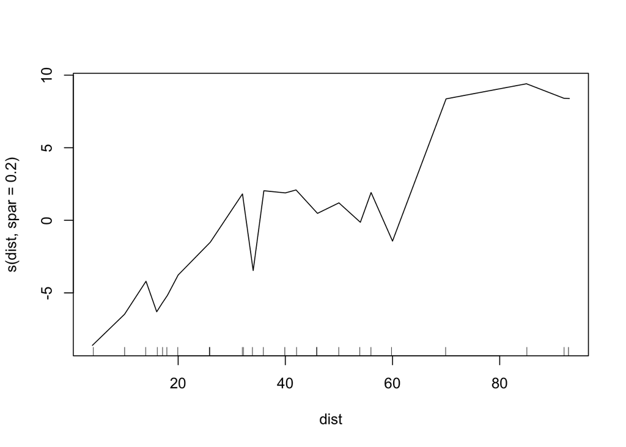

```r
plot(fit_gam(spval = .2))
```

Once the `mgcv` name space is loaded it breaks:

[figure not shown]

```r
library(ggplot2)
ggplot(cars, aes(x = dist, y = speed)) +
    geom_smooth(method = "gam") ## this loads the mgcv namespace
```

Now that the `mgcv` name space is loaded `plot.gam` (and probably other stuff) is broken.

```r
any(grepl("mgcv", loadedNamespaces()))
```

```
## [1] TRUE
```

```r
plot(fit_gam(spval = .2))
```

```
## Error in 1:object$nsdf: argument of length 0
```

The worst part is that the only way to recover is to restart your R session. Unloading the name space should work, but it doesn’t:

```r
unloadNamespace("mgcv")
any(grepl("mgcv", loadedNamespaces()))
```

```
## [1] FALSE
```

```r
plot(fit_gam(spval = .2))
```

```
## Error in 1:object$nsdf: argument of length 0
```

If you are using the `gam` package and `any(grepl("mgcv", loadedNamespaces()))` reports `TRUE`, you must restart your R session and take steps to avoid loading `mgcv`. This includes making sure `ggplot2` isn’t loading it to make predictions with `geom_smooth`.

Since you probably want to use `ggplot` to plot prediction lines from `gam` models you’ll need a work-around to do that without loading `mgcv`. The safest way is just to do the predictions yourself:

```r
library(ggplot2)
ggplot(transform(cars, pred = predict(gam(speed ~ s(dist, spar = .2), data = cars))),
       mapping = aes(x = dist, y = speed)) +
    geom_point() =
    geom_line(mapping = aes(y = pred))
```

[output not shown]